# A Temperatura Recente de um Projeto de Lei

## Conceito de Temperatura

A temperatura de uma proposição é um conceito criado com o objetivo de medir quão movimentada está a tramitação de um Projeto de Lei num determinado período, indicando quanto esforço tem sido empregado por atores do processo legislativo em avançar/barrar o projeto.

## Cálculo da temperatura

A temperatura de um PL pode ser calculada com diferentes granularidades/períodos (dia, semana, mês). Além disso, é possível escolher o tamanho da janela do histórico recente a ser considerado no cálculo (ex: os últimos 22 dias, ou as últimas 4 semanas). A temperatura de um período é definida como a quantidade de eventos ocorridos nesse período ponderados, estes pesos são dados de acordo com o tipo de evento (despacho, discussão e votação) além do local do evento também influenciar o peso (plenário, ccj, cft, comissões especiais e cae têm um peso maior). A função de temperatura é dada pela fórmula:

$$t = \sum_{j=0}^{n} (v_j)\alpha^j$$

onde:

- n é o tamanho da janela móvel a ser utilizada
- j é o índice da janela móvel a ser utilizada
- $\alpha$ é a taxa de decaimento (deve estar entre 0 e 1);
- $v_j$ é a quantidade de eventos ponderados (requerimentos, votações, etc) do período de índice $j$ na janela;
- $t$ é a temperatura recente do período;

## Exemplo

Vamos calcular a temperatura para um Projeto de Lei de exemplo.

Escolhemos o [PL 490/2007](http://camara.gov.br/proposicoesWeb/fichadetramitacao?idProposicao=345311), que trata da demarcação de terras indígenas. Vamos baixar os dados da proposição e da tramitação e em seguida reconhecer os eventos e fases, mostrando os últimos eventos ocorridos na tramitação do PL.

```r
#devtools::install_github('analytics-ufcg/agora-digital') #Descomentar para instalar o pacote
library(magrittr)
id <- 345311
casa <- 'camara'
prop <- agoradigital::fetch_proposicao(id,casa)
tram <- agoradigital::fetch_tramitacao(id,casa)
proc_tram <- agoradigital::process_proposicao(prop,tram,casa)
proc_tram %>%
  dplyr::select(data_hora, texto_tramitacao, sigla_local, evento) %>%
  dplyr::filter(!is.na(evento)) %>%
  utils::tail(6) %>%
  DT::datatable(rownames = F, data = )
```

| data_hora | texto_tramitacao | sigla_local | evento |
| --- | --- | --- | --- |
| 2019-07-10T18:47:00Z | Apresentacao do Requerimento n. 1940/2019, pelo Deputado Arthur Oliveira Maia (DEM/BA), que "Requer a tramitacao conjunta, nos termos regimentais, das proposicoes que menciona". | PLEN | req_apresentacao |
| 2021-05-12T09:42:00Z | Parecer do Relator, Dep. Arthur Oliveira Maia (DEM-BA), pela constitucionalidade,juridicidade, técnica legislativa e, no mérito, pela aprovação dos Projetos de Lei nºs 1.218/2007, 1.606/2015, 3.700/20… | CCJC | parecer_pela_aprovacao_com_substitutivo |
| 2021-05-25T20:56:00Z | Apresentação do Voto em Separado n. 2 CCJC, pela Deputada Joenia Wapichana (REDE/RR). | CCJC | voto_em_separado |
| 2021-05-26T09:00:00Z | Retirado de Pauta, por acordo. | CCJC | retirada_de_pauta |
| 2021-06-16T09:00:00Z | Vista conjunta aos Deputados Edio Lopes, Gervásio Maia, Joenia Wapichana, José Guimarães, Maria do Rosário, Paulo Teixeira e Rui Falcão. | CCJC | pedido_de_vista |
| 2021-06-16T09:26:00Z | Apresentação do Voto em Separado n. 3 CCJC, pela Deputada Joenia Wapichana (REDE/RR). | CCJC | voto_em_separado |

### Temperatura Semanal

Vamos calcular a temperatura recente para todo o histórico da tramitação do PL, agregando os eventos por semana e utilizando um decaimento de 10%. Os resultados podem ser vistos no gráfico abaixo.

#### Temperatura Semanal (pontos)

Os pontos pretos representam os valores da temperatura recente calculada para cada semana.

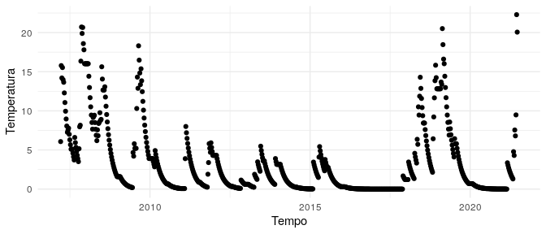

```r
pautas <- tibble::frame_data(~data, ~sigla, ~id_ext,    ~local, ~casa,  ~semana,    ~ano)
hist_temperatura_semanal <- agoradigital::get_historico_temperatura_recente(proc_tram, granularidade = 's', decaimento = 0.1, pautas = pautas)

ggplot2::ggplot(hist_temperatura_semanal, ggplot2::aes(x=periodo, y=temperatura_recente)) +
  ggplot2::xlab("Tempo") +
  ggplot2::ylab("Temperatura") +
  ggplot2::geom_point() +
  ggplot2::theme_minimal()
```

#### Temperatura Semanal (linha)

Para ter uma visualização menos poluída, vamos mostrar uma linha, ao invés dos pontos.

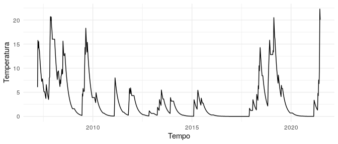

```r
hist_temperatura_semanal %>%
  ggplot2::ggplot(ggplot2::aes(x=periodo, y=temperatura_recente)) +
  ggplot2::geom_line() +
  ggplot2::xlab("Tempo") +
  ggplot2::ylab("Temperatura") +
  ggplot2::theme_minimal()
```

#### Temperatura Semanal (curva suavizada)

Agora vamos aplicar uma suavização à curva de temperatura.

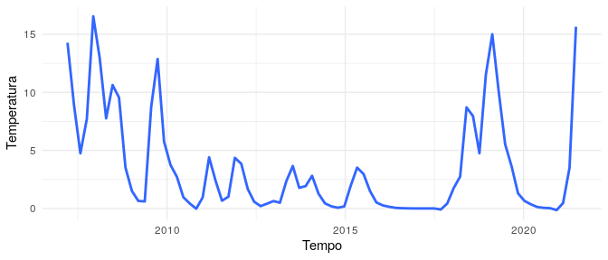

```r
hist_temperatura_semanal %>%
  ggplot2::ggplot(ggplot2::aes(x=periodo, y=temperatura_recente)) +
  ggplot2::geom_smooth(span = .05, se = F) +
  ggplot2::xlab("Tempo") +
  ggplot2::ylab("Temperatura") +
  ggplot2::theme_minimal()
```

#### Temperatura Semanal (curva suavizada - últimos 3 meses)

Podemos também ter uma visualização mais detalhada, olhando apenas os últimos 3 meses (~ 12 semanas) da tramitação do PL, e mostrando a quantidade de eventos ocorridos a cada semana.

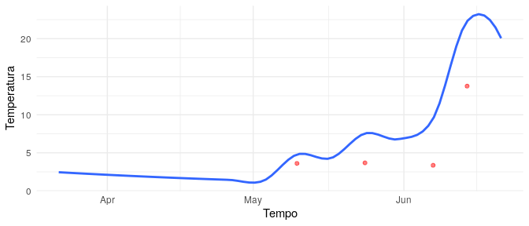

```r
start_date <- dplyr::last(proc_tram$data_hora) - lubridate::days(90)
hist_temperatura_semanal_3_meses <- hist_temperatura_semanal %>%
  dplyr::filter(periodo >= start_date)

hist_temperatura_semanal_3_meses %>%
  ggplot2::ggplot(ggplot2::aes(x=periodo, y=temperatura_recente)) +
  ggplot2::geom_smooth(span = .3, se = F) +
  ggplot2::geom_point(ggplot2::aes(x=periodo, y=temperatura_periodo), colour='red', alpha=0.5, subset(hist_temperatura_semanal_3_meses, temperatura_periodo > 0)) +
  ggplot2::xlab("Tempo") +
  ggplot2::ylab("Temperatura") +
  ggplot2::theme_minimal()
```